# 02 · Análisis del Problema *(FDR Sección 3.1)*

Tres preguntas que el sistema debe responder en tiempo real:

| # | Pregunta | Señal usada |
| --- | --- | --- |
| 1 | ¿El conductor está fumando o en llamada? | cabin crop → behavior model |
| 2 | ¿La placa es legible? | plate detector → fast-plate-ocr |
| 3 | ¿El vehículo conduce erráticamente? | trayectoria del bbox → swerving score |

Este notebook analiza por qué cada señal es difícil y qué límites tiene.

### Caso 1 — Visibilidad del comportamiento (smoking / phone)

[figure not shown]

**Lectura.** El comportamiento (cigarrillo, teléfono) es visible en el recorte de la cabina pero no existe clase COCO para ello — requiere un modelo entrenado en este dominio nocturno. COCO class 67 (cell phone) no detecta nada en estas condiciones de iluminación y ángulo.

### Caso 2 — Límite de la placa: localización vs legibilidad OCR

[output not shown]

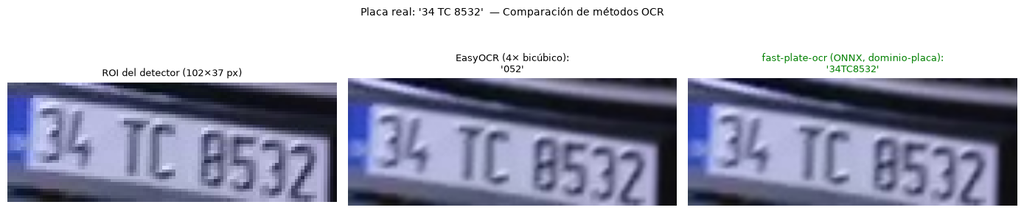

```
Placa real    : 34 TC 8532
EasyOCR       : '052'   <- confunde caracteres
fast-plate-ocr: '34TC8532'   <- correcto (modelo entrenado en placas)
Tamaño ROI    : 102x37 px a 464p
```

**Lectura.** EasyOCR confunde "34 TC 8532" porque es un OCR genérico no entrenado en placas. `fast-plate-ocr` mejora claramente la lectura en el ROI válido mostrado, pero para el FDR se reporta como **OCR experimental**: necesita tabla de aciertos/fallos por frame y más videos antes de reclamar generalización. El límite sigue siendo la baja resolución del ROI (~30-40 px de alto) y las condiciones nocturnas.

### Caso 3 — Conducción errática (tekno-03): señal de trayectoria

```
Vehículo detectado: caja 463,119→672,279  centro (567,199)
Técnica: el centro X del bbox por cada frame forma la trayectoria;
desviación lateral y cambios de dirección → swerving_score (0-1).
```

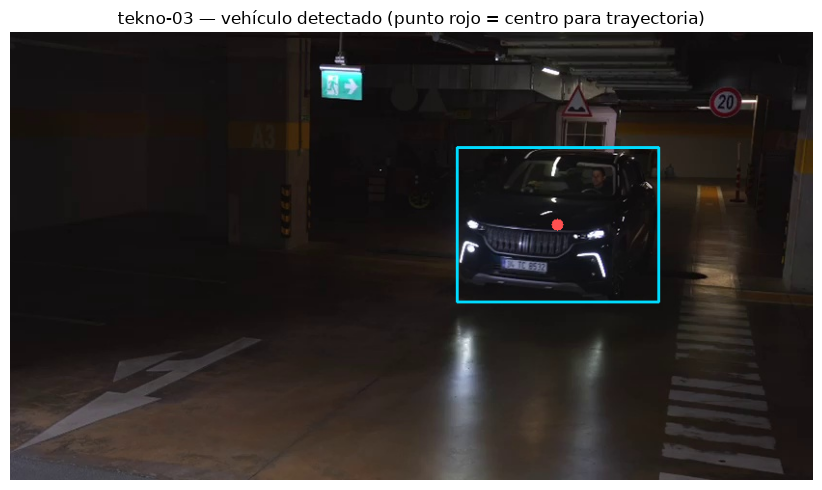

**Lectura.** Tekno-03 no tiene objeto visible (cigarrillo/teléfono) en la cabina — el riesgo es **conducción errática** detectada por la trayectoria del centro del bbox a lo largo del video. La señal es el desplazamiento lateral acumulado y los cambios de dirección, no una clasificación de objetos.